# EDHEC PhD Finance 2022 - Econometrics Homework

Giovanni Maffei, Timo Predoehl

Compute also for each sample size T the distribution of the $R^2$ of the MC simulations with either 7 separate histograms, or one unique figure where you report on the y-axis the 5%, 10% 25%, 50%, 75%, 90% and 95% quantiles of the distributions of the simulated $R^2$, and on the x-axis you have T = 6, 12, 60, 120, 240, 360, 480.

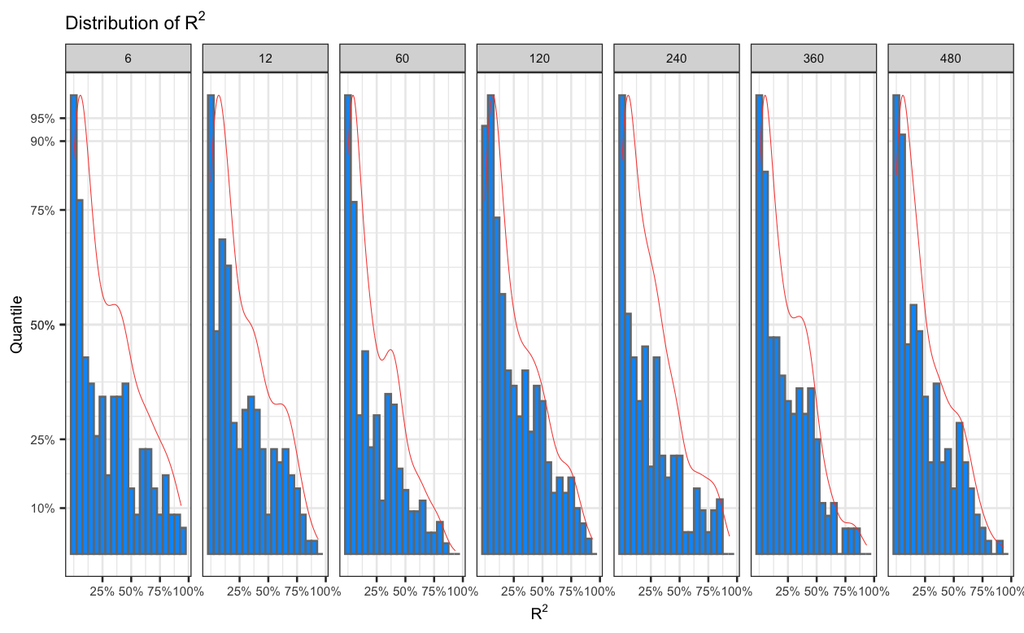

Similarly (either with histograms, or with one plot of the quantiles) report the distributions of the estimates t-statistics for the test of the null H0 : $\beta_2 = 0$

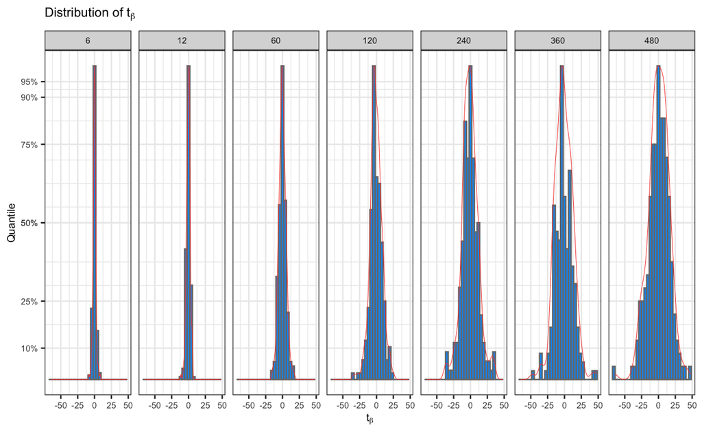

Compute the empirical rejection frequencies (that is the empirical size of the tests), which is exactly the figure 14.1 in Davidson MacKinnon (2005, book).

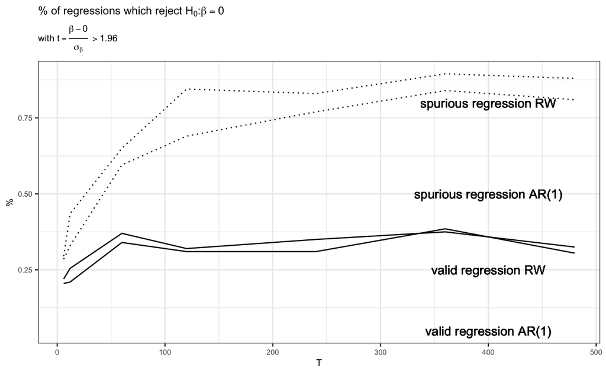

Spurious regression as outlined in Davidson MacKinnon occurs for two reasons:

The $H_0: \beta_2=0$ tested with the model (14.12)
$$y_t = \beta_1 +
\beta_2y_{t-1} + v_t$$
implies a DGP’: $y_t = \beta_1 + v_t$, when $y_t$ is actually generated using DGP (14.01) $y_t = y_{t-1} + v_t, y_0=0, v_t \sim iidN(0,1)$.

The wrongly specified $H_0$ is rejected with increasing frequency in n. This merely confirms that $y_t$ is not generated by the implied DGP’. Correctly specifying the model as (14.13)
$$y_t = \beta_1 + \beta_2 x_t + \beta_3 y_{t-1} +
v_t$$
and testing $H_0:\beta_2=0$, implying $\beta_3=1$ reduces the model to the actual DGP (14.01). This treatment, however, does not completely eliminate the problem i.e. leaves the rejection rate still significantly above 0.

For $\hat{\beta}$ to converge to $\beta_0$ asymtotically, the bias $(\hat{\beta} - \beta_0)$ must be $O_p(1)$:
$$\begin{align*}
(\hat{\beta} - \beta_0) &= (X'X)^{-1}X'u, with\\
(X'X)^{-1} &\in O_p(n^{-1}) and \\
X'u &\in O_p(n^{.5}). consequently:\\
n^{.5}(\hat{\beta} - \beta_0) &= n^{.5}(X'X)^{-1}X'u =
n^{.5} O_p(n^{-1})O_p(n^{.5}) = O_p(1)
\end{align*}$$

The relevant assumption to be tested is therefore is $(X'X) \in n^{.5} O_p(n^{-1})$.

The random walk (14.01) is I(1), due to:
$$\begin{align*}
w_t &= w_{t-1}+\epsilon_t \\
w_t - w_{t-1} &= \epsilon_t \\
(1-L)w_t &= \epsilon_t \\
(1-\phi(z))w_t &= \epsilon_t \\
\phi(z) &= 1
\end{align*}$$
Consequently, both $x_t$ and $y_t$ are I(1).

Further, (14.01) reduces to $w_t = \sum^t_{s=1}{\epsilon_s}$, which enters as X’X or:
$$\begin{align*}
\sum_{t=1}^n \left( \sum_{r=1}^t \sum_{s=1}^t \right) \epsilon_r
\epsilon_s &= \sum_{t=1}^n \sum_{r=1}^t E(\epsilon_r^2),
\epsilon_r\epsilon_s=0 \;\forall r \ne s\\
\sum_{t=1}^n \sum_{r=1}^t \sigma^2 &= \sum_{t=1}^n \sum_{r=1}^t 1
\\
\sum_{t=1}^n t &= \frac{1}{2}n(n+1)
\end{align*}$$

Consequently, given (14.01) being I(1), $X'X \in O_p(n^2)$ and therefore cannot possibly converge to a finite probability limit. The bias $(\hat{\beta} - \beta_0)$ therefore does not converge asymptotically in probability.